# An exploration of genotype-phenotype correlation in Sorghum bicolor

Team 5: Stacey Butler, Michael Livesay, Robert Rennie, Sarka Petrickova, Mary Angelica Tursi  
June 9, 2017

### Introduction

- *Genotype* is an organism’s full hereditary information.
- *Phenotype* is an organism’s actual observed properties, such as morphology, development, or behavior.

### Questions

- Can we find correlations between genotype and phenotype data?
- What clusters can be seen in genotypes using different methods for measuring distance between two genotypes?

### Introduction

[figure not shown]

http://passel.unl.edu/Image/siteImages/ChromgendnaLG.jpg

### Introduction

[figure not shown]

http://images.slideplayer.com/24/7019791/slides/slide_21.jpg

### Data: Genotype file - VCF (from Terraref)

.vcf file consists of three regions:

- **meta**: info about the file and its creation
- **fix**: reference table

| location | reference | alternate |
| --- | --- | --- |
| 340 | C | G |
| 1200 | A | C |

- **gt**: genotype region contains information about each variant for each sample

| location | culivar1 | cultivar2 | cultivar3 |
| --- | --- | --- | --- |
| 340 | 0/0 | 0/1 | 1/0 |
| 1200 | 1/1 | 0/0 | 0/1 |

### Data: Phenotype files - CSV (Genesys)

Two types of data:

- nutrition: Fat, Fiber, Mtblzble_Enrgy, NetEnGain, NetEnLact, NetEnMaint, Phosphorus, Protein, Starch, TotalNutrients
- growth: kercolor, kercover, kershape, paniclelgt, plantcol, planthgt, rust, seedtype,…

### Data: Combining files

- 304 cultivars in genotype data
- thousands of cultivars in phenotype nutrition and growth data
- only 48 cultivars with both genotype and phenotype nutrition data
- only 19 cultivars with both genotype and phenotype growth data

### Methods

- measuring distance: three kinds of distance: for two genomes \( g_1,g_2 \):
  - \( |\{i: g_1[i]\neq g_2[i] \}| \)
  - \( \sum |g_1[i]-g_2[i]| \)
  - Euclidean distance
- clustering: We used the hclust function and the dendexpend package to graphically illustrate the clusters

### Methods

- heatmaps: a table of colors which illustrates how values of traits correspond to genomic clusters and other traits
  - used heatmap function
- traits: found matches of two samples for different traits:
  - 19 genomes with growth traits
  - 48 genomes with nutrition traits
  - some traits, such as plant color, are qualitative, so we quantified them according to a natural scale

### Results

- Clustering: hclust
- Heatmaps: clustered cultivars versus nutrition traits
- Correlation: cultivars versus nutrition traits
- Topological data analysis

### Results: Clustering

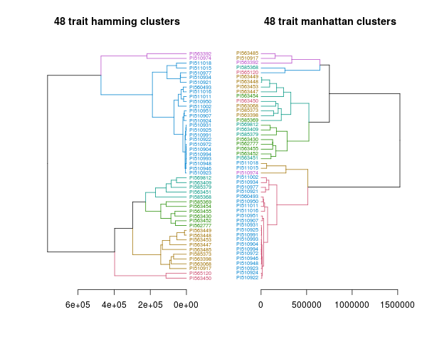

### Results: Clustering

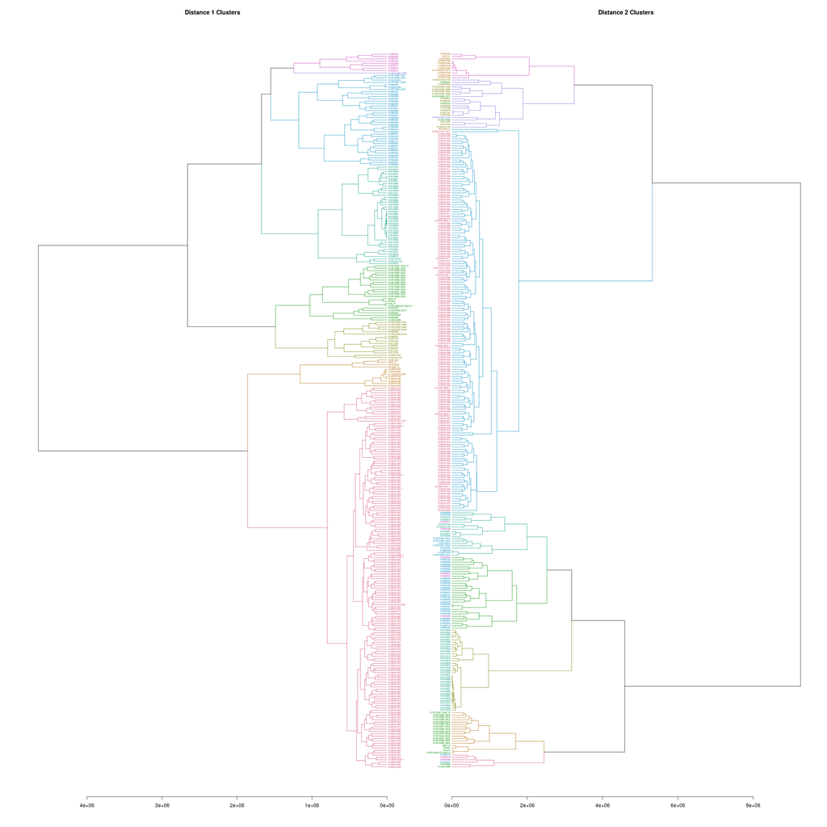

### Results: Heatmaps

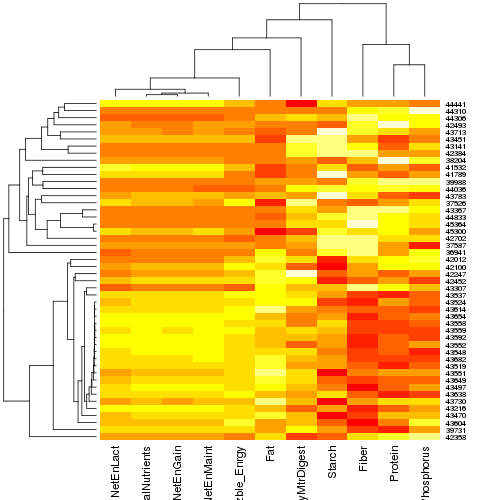

### Results: Correlation

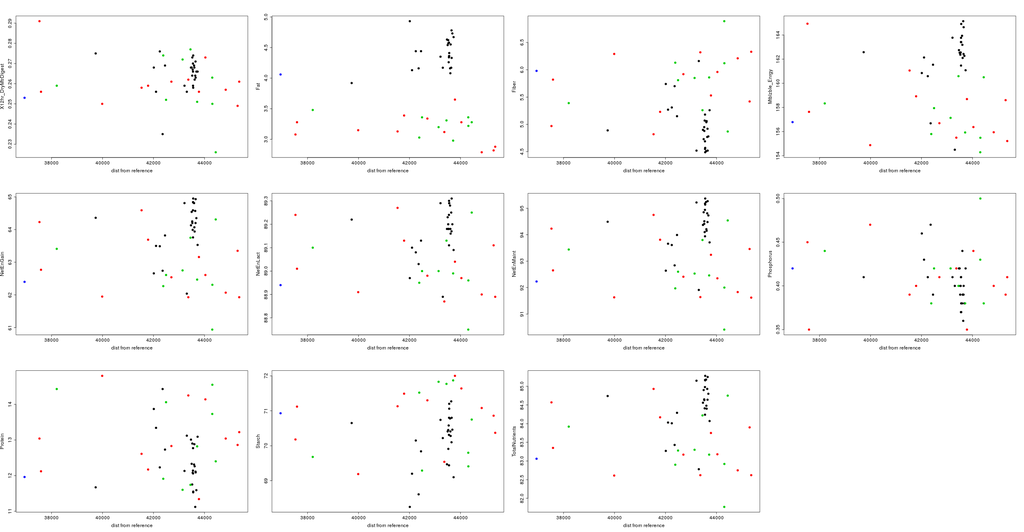

### Results: Topological data analysis

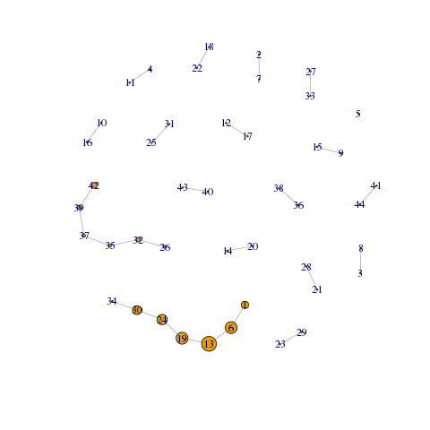

### Conclusion & Next Steps

- we have some tenuous connections between genotypes and phenotypes…
- … but in order to say anything meaningful we need more data

## “Things that you think will take two weeks will probably take four.”